# Time-Series Forecasting of Banana Prices

\[ \newcommand{\Prob}{\operatorname{P}} \newcommand{\E}{\operatorname{E}} \newcommand{\Var}{\operatorname{Var}} \newcommand{\Cov}{\operatorname{Cov}} \newcommand{\se}{\operatorname{se}} \newcommand{\re}{\operatorname{re}} \newcommand{\ybar}{{\overline{Y}}} \newcommand{\phat}{{\hat{p}}} \newcommand{\that}{{\hat{T}}} \newcommand{\med}{{\tilde{Y}}} \newcommand{\Logit}{{\operatorname{Logit}}} \]

## Table of Contents

## Introduction

- Collected from the Federal Reserve Bank of St. Louis
- Bananas are typically consumed fresh
- Look for Seasonality
- Look for Trend

## Methodology

## Original Time Series Plot

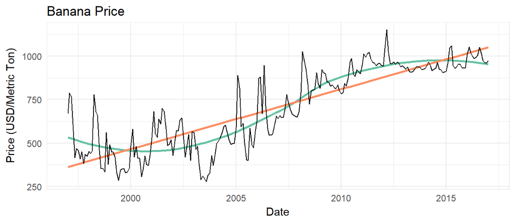

## Original Seasonal Plot

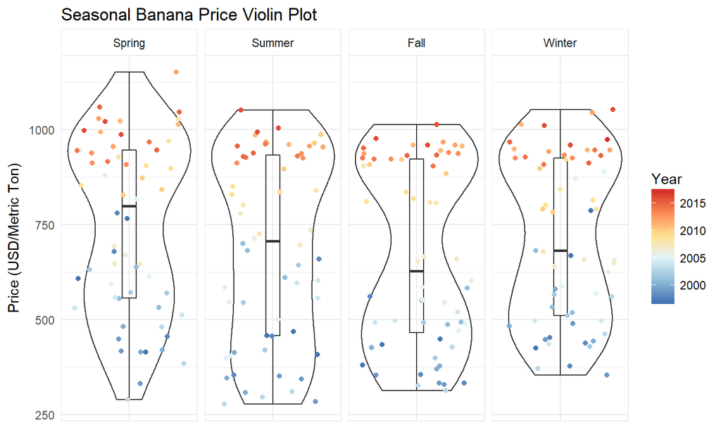

## Lagged Scatter Plot

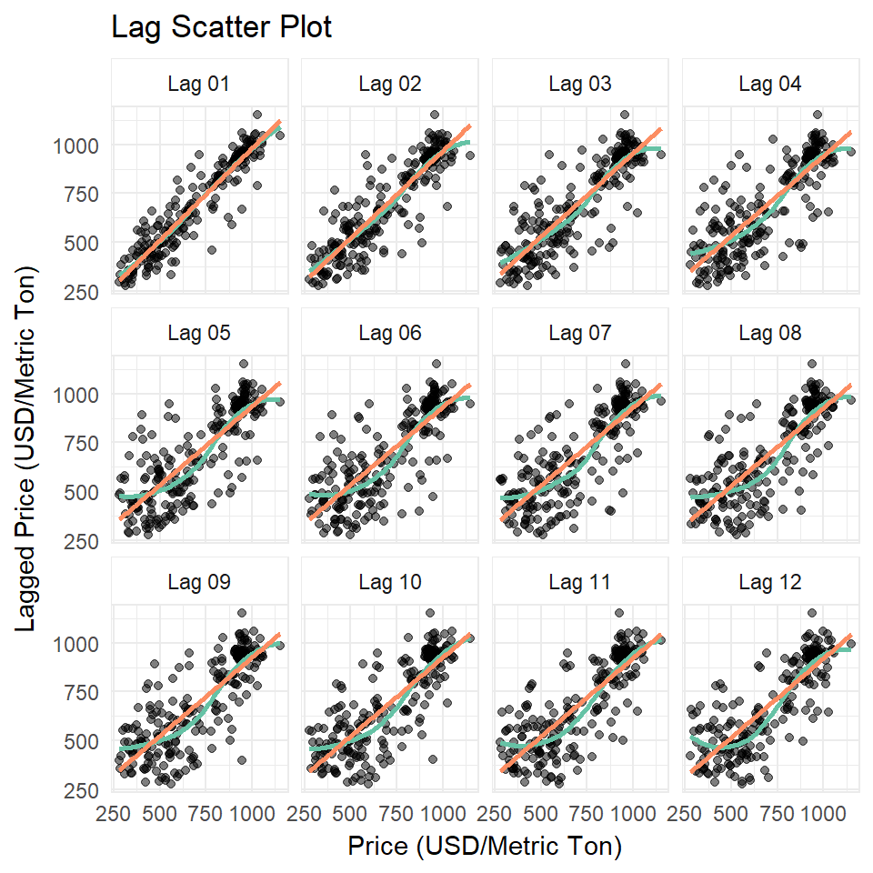

## Autocorrelation Function

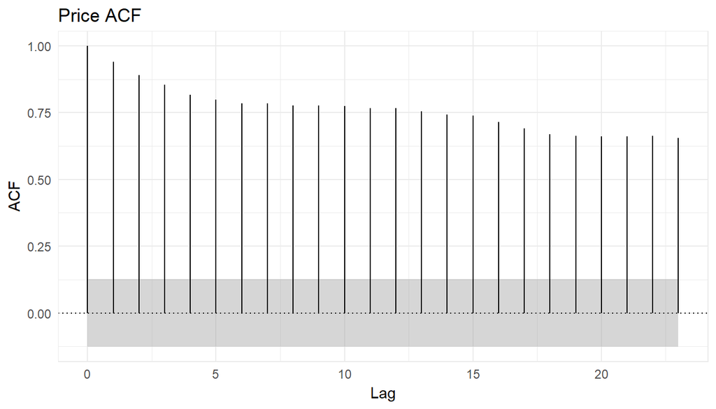

## Partial Autocorrelation Function

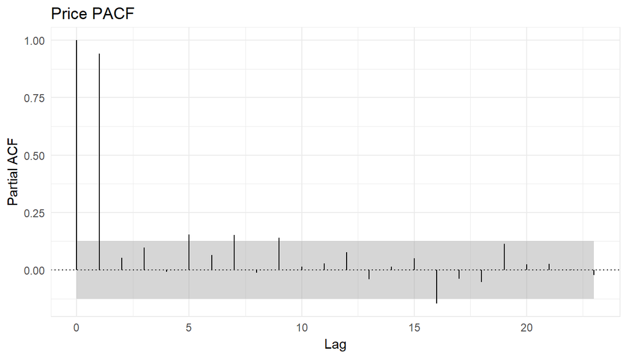

## Transformation Time-Series Plot

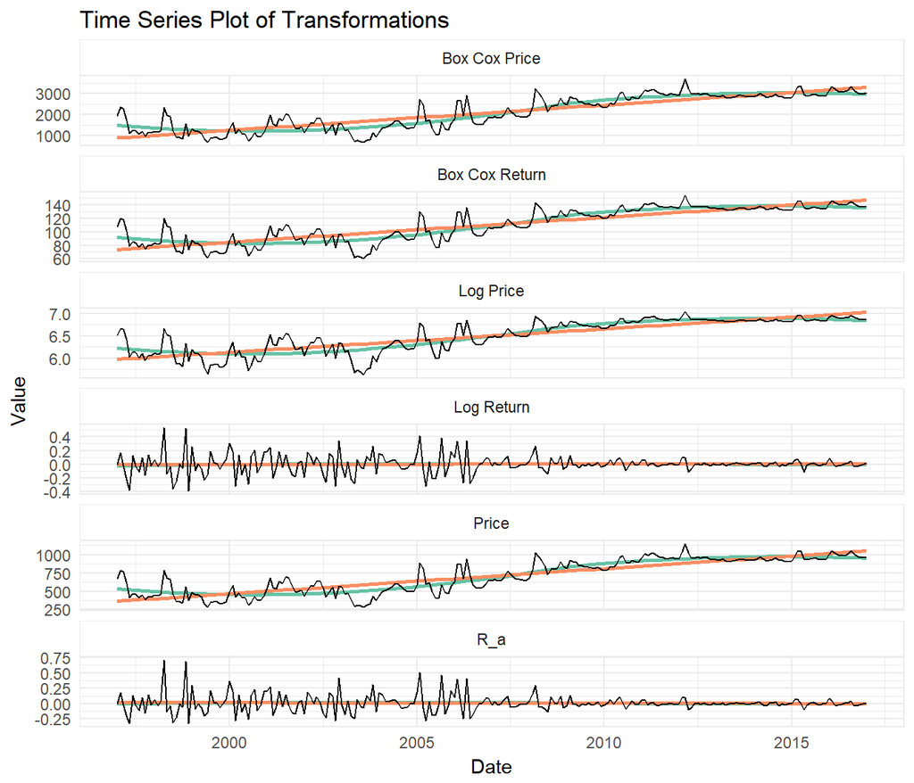

## Transformation Autocovariance Function

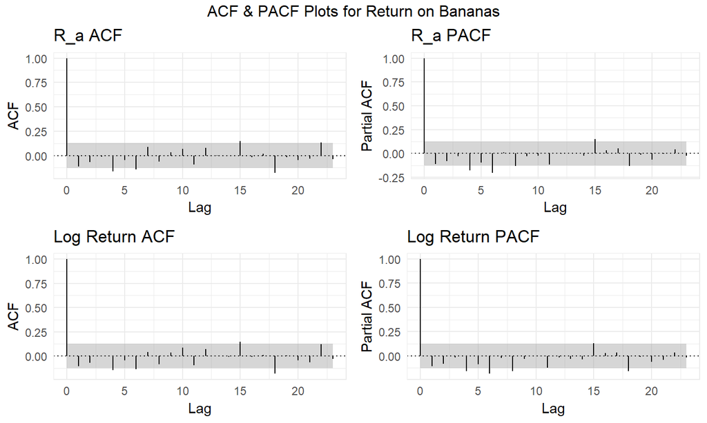

## Decomposition of Transformation

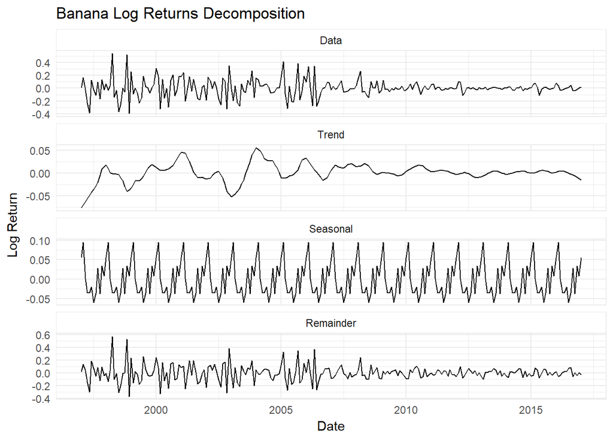

## ADF Test (Dickey's Test)

```
##
##  Augmented Dickey-Fuller Test
##
## data:  .$Price
## Dickey-Fuller = -3.7667, Lag order = 6, p-value = 0.02131
## alternative hypothesis: stationary
```

```
##
##  Augmented Dickey-Fuller Test
##
## data:  .$`Log Return`
## Dickey-Fuller = -8.1002, Lag order = 6, p-value = 0.01
## alternative hypothesis: stationary
```

## Model Selection

## Auto ARIMA

\[\phi(B)\Phi(B^s)Y_t= \theta(B)\Theta(B^s)Z_t \] where \[\phi(z) = 1-\phi_1(z)-...-\phi_pz^p,\Phi(z) = 1-\Phi_1(z)-...-\Phi_pz^p \] \[\theta(z) = 1+\theta_1z+...+\theta_qz^q, \Theta(z) = 1+\Theta_1z+...+\Theta_qz^q \] Auto-ARIMA(1,0,1) where \[\phi(z) = 1-0.7300z\] \[\theta(z) = 1-0.9256z\]

## Minimum AIC

Minimum AIC

| p | d | q | P | D | Q | AIC | BIC |
| --- | --- | --- | --- | --- | --- | --- | --- |
| 1 | 0 | 1 | 1 | 1 | 0 | -294.3741 | 661.6259 |
| 1 | 0 | 1 | 1 | 1 | 1 | -294.3741 | 661.6259 |
| 1 | 0 | 1 | 1 | 0 | 0 | -294.3741 | 661.6259 |
| 1 | 0 | 1 | 1 | 0 | 1 | -294.3741 | 661.6259 |
| 1 | 0 | 1 | 0 | 0 | 0 | -294.3741 | 661.6259 |
| 1 | 0 | 1 | 0 | 0 | 1 | -294.3741 | 661.6259 |
| 1 | 0 | 1 | 0 | 1 | 1 | -294.3741 | 661.6259 |
| 1 | 0 | 1 | 0 | 1 | 0 | -294.3741 | 661.6259 |

## Minimum BIC

Minimum BIC

| p | d | q | P | D | Q | AIC | BIC |
| --- | --- | --- | --- | --- | --- | --- | --- |
| 0 | 1 | 0 | 0 | 0 | 1 | -87.16703 | 151.833 |
| 0 | 1 | 0 | 0 | 0 | 0 | -87.16703 | 151.833 |
| 0 | 1 | 0 | 0 | 1 | 1 | -87.16703 | 151.833 |
| 0 | 1 | 0 | 0 | 1 | 0 | -87.16703 | 151.833 |
| 0 | 1 | 0 | 1 | 1 | 1 | -87.16703 | 151.833 |
| 0 | 1 | 0 | 1 | 1 | 0 | -87.16703 | 151.833 |
| 0 | 1 | 0 | 1 | 0 | 0 | -87.16703 | 151.833 |
| 0 | 1 | 0 | 1 | 0 | 1 | -87.16703 | 151.833 |

\[\phi(B)\Phi(B^s)Y_t= \theta(B)\Theta(B^s)Z_t \] where \[\phi(z) = 1-\phi_1(z)-...-\phi_pz^p,\Phi(z) = 1-\Phi_1(z)-...-\Phi_pz^p \] \[\theta(z) = 1+\theta_1z+...+\theta_qz^q, \Theta(z) = 1+\Theta_1z+...+\Theta_qz^q \] AIC (1,0,1) where \[\phi(z) = 1-0.7573z\] \[\theta(z) = 1-0.9568z \]

## Forecasting Banana Price

## Log Return Comparison

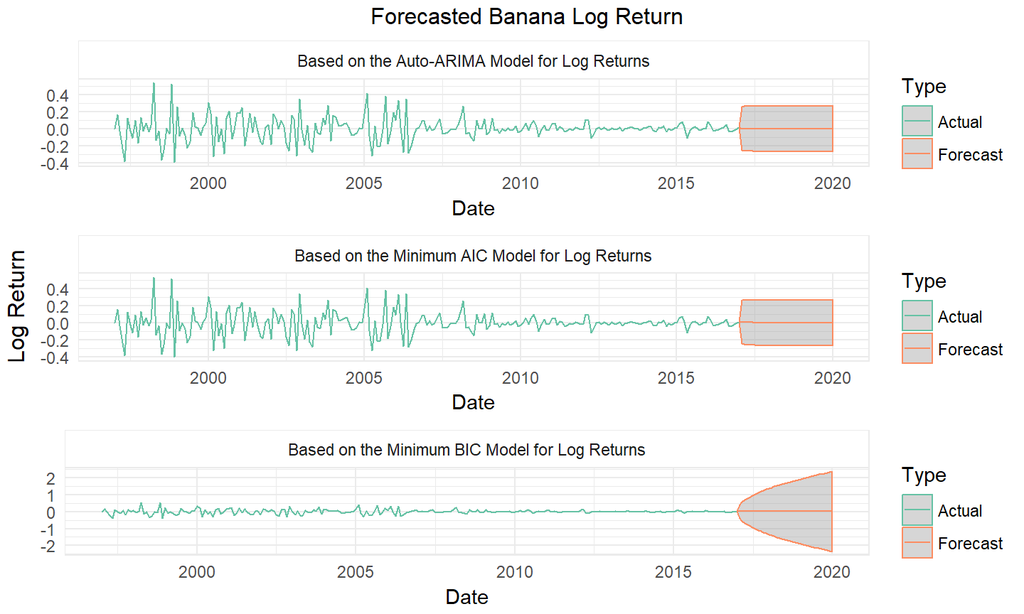

## Price Comparison

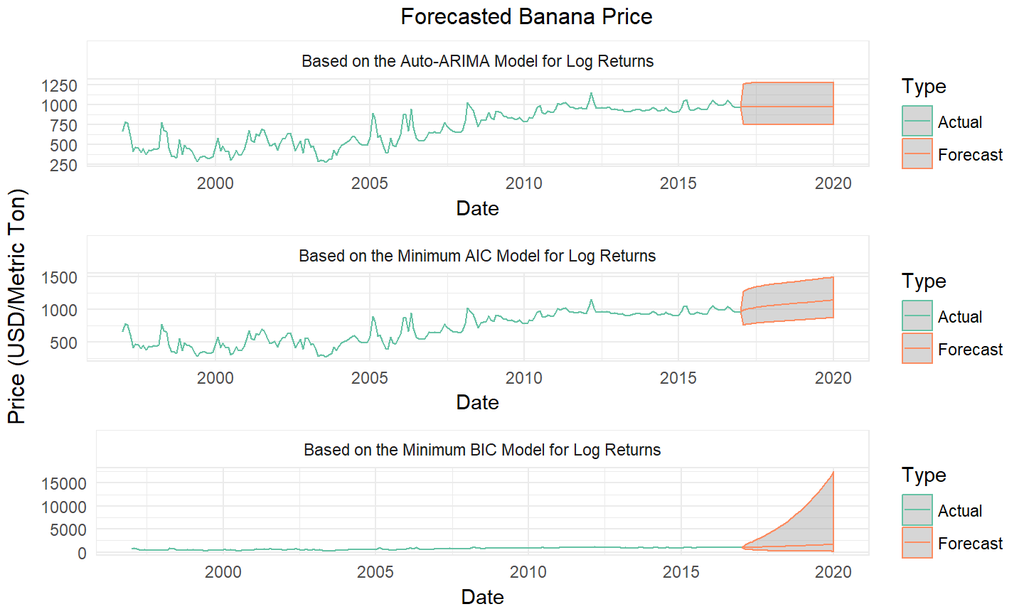

## Accuracy Comparison

Comparison of Model Accuracy

| Model | ME | RMSE | MAE | MASE | ACF1 |
| --- | --- | --- | --- | --- | --- |
| Auto-ARIMA | 0.0067125 | 0.1295891 | 0.0834648 | 0.6522896 | 0.0138483 |
| Minimum AIC | -0.0042167 | 0.1290165 | 0.0839851 | 0.6563556 | 0.0106646 |
| Minimum BIC | 0.0000605 | 0.2005319 | 0.1274257 | 0.9958506 | -0.5168530 |

## Model Diagnostics

## White Noise

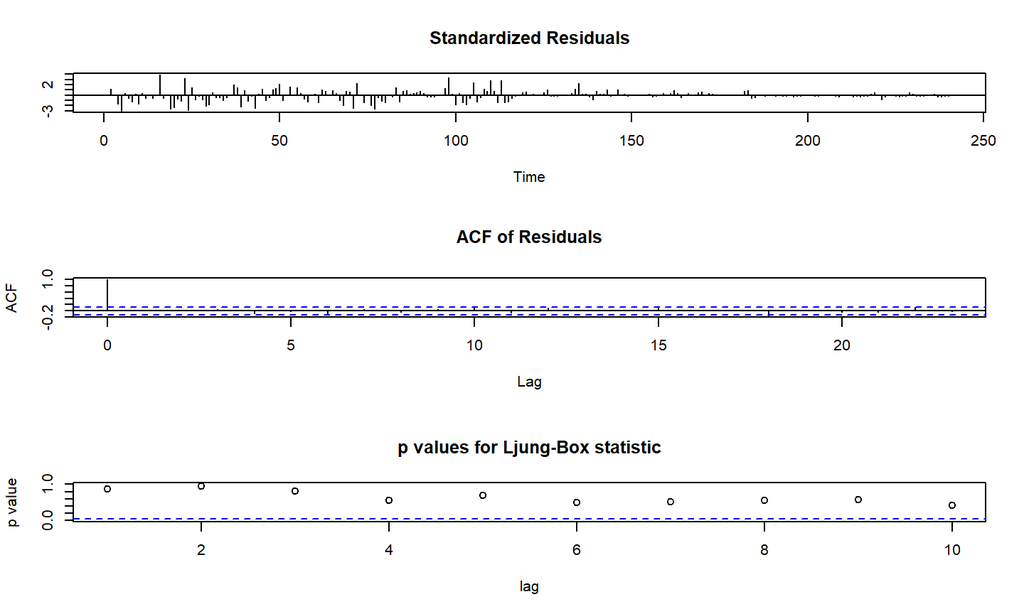

## Normality of Residuals

```
##
##  Shapiro-Wilk normality test
##
## data:  residuals(banana_aic_arima$`1`)
## W = 0.92387, p-value = 8.614e-10
```

```
##
##  Jarque Bera Test
##
## data:  residuals(banana_aic_arima$`1`)
## X-squared = 69.562, df = 2, p-value = 7.772e-16
```

## Constant Variance

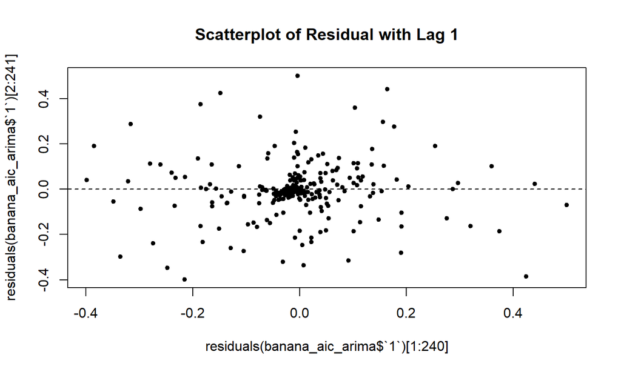

## Results

## Model

\[ \phi(B)\Phi(B^s)Y_t= \theta(B)\Theta(B^s)Z_t \] \[ \phi(z) = 1-\phi_1(z)-...-\phi_pz^p,\Phi(z) = 1-\Phi_1z-...-\Phi_pz^p \]

ARIMA (1,0,1) \[ \phi(z) = 1-0.7573z \] \[ \theta(z) = 1-0.9568z \]

## Appendix

## References

[1] Federal Reserve Bank of St.Louis (FRED). (2017, July 12). Global price of Bananas. Retrieved April 09, 2018, from https://fred.stlouisfed.org/series/PBANSOPUSDM

[2] Britannica, T. E. (2018, March 15). Banana. Retrieved April 09, 2018, from http://www.britannica.com/plant/banana-plant

[3] Banana Link. (n.d.). Retrieved April 09, 2018, from http://www.bananalink.org.uk/